# dplyr

04 de febrero del 2021

## dplyr

### Gramática de manejo de datos

Este paquete permite el manejo de datos usando una gramática con verbos consistentes y que permiten resolver de forma clara y concisa casi cualquier procesamiento de datos.

Entre algunas de sus ventajas tenemos:

- Sintaxis interpretable
- Es extensible para usar con **bases de datos**, **spark** o **data.table**
- Compatible con el resto de paquetes que forman parte de **tidyverse**Es una colección de paquetes que permiten el manejo de datos manteniendo un gramática en común

## dplyr

### Verbos Básicos

| Comando | ¿Que hace? |
| --- | --- |
| filter() | Filtra los renglones con base en valores |
| select() | Selecciona columnas por nombre o posición |
| mutate() | Agrega nuevas variables |
| arrange() | Ordena el dataset con base en un factor |
| summarise() | Calcula calculos agrupados |

## dplyr

### Verbos Básicos versión gráfica

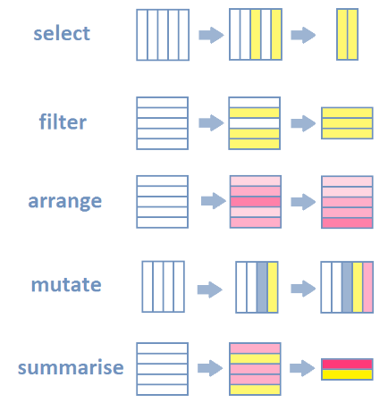

## dplyr

### ¿Como se usan?

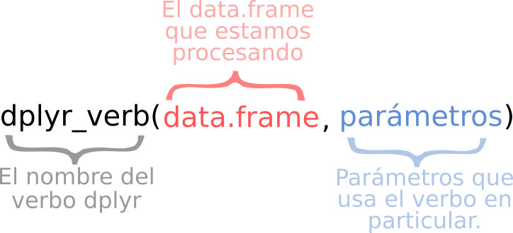

## dplyr

### Ejemplo de uso I

```r
library(curso.feminismo.datos)
library(dplyr)
select(situacion_laboral_madre, Año, Estudiante)
```

```
## # A tibble: 11 x 2
##    Año    Estudiante
##    <chr>       <dbl>
##  1 2009.0       5.37
##  2 2010.0       5.92
##  3 2011.0       6.91
##  4 2012.0       7.76
##  5 2013*        7.70
##  6 2014*        9.00
##  7 2015*       10.8
##  8 2016*       10.6
##  9 2017*       11.3
## 10 2018*       12.1
## 11 2019*       12.3
```

## dplyr

### Ejemplo de uso II

```r
filter(situacion_laboral_madre, Año == "2013*")
```

```
## # A tibble: 1 x 6
##   Año   Quehaceres_hogar Estudiante Incapacitado_trabaj… Jubilado_pension…  Otra
##   <chr>            <dbl>      <dbl>                <dbl>             <dbl> <dbl>
## 1 2013*             76.6       7.70               0.0129            0.0259  15.7
```

## dplyr

### Ejemplo III

```r
mutate(nacimiento_lugar_residencia, año_entero = as.integer(substr(Año, 1, 4)))
```

```
## # A tibble: 30 x 5
##    Año    Área_rural Área_urbana No_especificado año_entero
##    <chr>       <dbl>       <dbl>           <dbl>      <int>
##  1 1990.0       40.1        59.2           0.639       1990
##  2 1991.0       40.8        58.2           0.957       1991
##  3 1992.0       37.6        61.7           0.626       1992
##  4 1993.0       36.5        62.6           0.858       1993
##  5 1994.0       35.3        63.7           0.940       1994
##  6 1995.0       38.2        61.0           0.801       1995
##  7 1996.0       38.3        60.5           1.14        1996
##  8 1997.0       36.8        61.9           1.37        1997
##  9 1998.0       35.3        62.9           1.81        1998
## 10 1999.0       35.8        61.7           2.53        1999
## # … with 20 more rows
```

## dplyr

### Pipe

Una característica que se distintiva de esta gramática de procesamiento de datos es el uso de una **pipe** que se define como el símbolo `%>%`.

Este símbolo permite encadenar varias instrucciones o verbos que se ejecutaran uno tras otro.

En este encadenamiento se puede obviar el paso del **data.frame** que se esta procesando, considerandolo como el primer argumento de cada verbo.

[figure not shown]

## dplyr

### Encadenando comandos

Una de las ventajas de esta gramática es que estos comandos se pueden usar de forma encadenada uno tras el otro.

Esto se puede hacer mediante el operador pipe

```r
situacion_laboral_madre %>%
  filter(Año == "2013*") %>%
  mutate(año_entero = as.integer(substr(Año, 1, 4))) %>%
  select(año_entero, Estudiante, Otra)
```

```
## # A tibble: 1 x 3
##   año_entero Estudiante  Otra
##        <int>      <dbl> <dbl>
## 1       2013       7.70  15.7
```

## dplyr

### Comando `summarise()`

Este comando permite reducir una columna a un valor con base en la función que nosotros usemos.

```r
situacion_laboral_madre %>%
  mutate(año_entero = as.integer(substr(Año, 1, 4))) %>%
  select(año_entero, Estudiante) %>%
  summarise(sum_estudiante = sum(Estudiante))
```

```
## # A tibble: 1 x 1
##   sum_estudiante
##            <dbl>
## 1           99.8
```